# II. Prediction of SiteEnergyUse for Project 3 ML (Seattle Building Energy Consumption)

## Contents

1. Preparing the Data for the Prediction of SiteEnergyUse(kBtu)
   1. Transforming the target
   2. Selecting all the columns that will be used for the iteration and train_test_split the data
   3. Creating all possible combinations of columns in set 1 and set 2
2. Performing the ML Models Test
   1. Iteration and testing
   2. Analysis of the tested models
      1. Best test
      2. Score analysis
      3. Training time analysis
      4. Errors and score of each model
   3. Selecting the best model and best parameters to perform the final tests on few additional columns
      1. Dummy models on the target
      2. Perform tests on few additional columns using the best model
         1. Predicted versus real value of the target
         2. Features importance
      3. Perform a final test on 'ENERGYSTARScore' column
         1. Predicted versus real value of the target
         2. Features importance
   4. Summary

```python
import numpy as np
import pandas as pd
import matplotlib.pyplot as plt
import seaborn as sns
import scipy.stats as st
import missingno as msno
import os

from stdnum.ean import *

from sklearn.experimental import enable_iterative_imputer
from sklearn.impute import IterativeImputer, KNNImputer
from sklearn.model_selection import train_test_split, GridSearchCV, cross_val_score
from sklearn.preprocessing import RobustScaler, StandardScaler, PowerTransformer, MinMaxScaler, OneHotEncoder
from sklearn.pipeline import Pipeline, make_pipeline
from sklearn.compose import ColumnTransformer, TransformedTargetRegressor
from sklearn.linear_model import LinearRegression, Ridge, Lasso, ElasticNet
from sklearn.ensemble import RandomForestRegressor
from sklearn.neighbors import KNeighborsRegressor
from sklearn.svm import SVR
from sklearn.decomposition import PCA
from sklearn.metrics import *
from sklearn import dummy
from sklearn.kernel_ridge import KernelRidge

from itertools import combinations

from sklearn.inspection import permutation_importance

from xgboost import XGBRegressor

import statsmodels.api

import time

sns.set()
```

```python
# To display all columns
pd.set_option('display.max_columns', None)

# Read the dataset
building_df_clean = pd.read_csv('building_df_cleaned.csv',
                                sep='\t', low_memory=False)
print('The size of the table is', building_df_clean.shape[0],
      'rows, and', building_df_clean.shape[1], 'columns.')
```

```
The size of the table is 1341 rows, and 41 columns.
```

## 1. Preparing the Data for the Prediction of SiteEnergyUse(kBtu)

The test will consist of three phases:

**Phase 1:** We will first select the columns that will be used for iteration. Then we will divide them into two sets, one without and one with the feature engineering. Then we will iterate on each set that will be used for this phase models testing.

- For the Y target, we will perform log transformation on SiteEnergyUse(kBtu) and test the models with and without log transformation.
- For the X features, we will use 'PropertyGFATotal', 'PropertyGFABuilding(s)', 'LargestPropertyUseTypeGFA', 'PrimaryPropertyType', 'ZipCode', 'column.endswith('_GFAratio')' and will iterate on them according to two sets:
  - Set_1:
    - Iteration on all possible combinations from 'PropertyGFATotal', 'PropertyGFABuilding(s)', 'LargestPropertyUseTypeGFA', 'PrimaryPropertyType', 'ZipCode'
  - Set_2:
    - Iteration on all possible combinations from 'PropertyGFATotal', 'PropertyGFABuilding(s)', 'column.endswith('_GFAratio')', 'ZipCode'

**Phase 2:** After selecting the best columns from phase 1, best model and parameters, we will add these columns for testing:

- 'BuildingAge', 'NumberofFloors', 'BuildingType', 'PropertyUseTypeCount', 'BuildingDecade', and 'EnergySourceCount'

**Phase 3:** After selecting the final list of columns from phase 1 and 2, we do the final test on 'ENERGYSTARScore'

### A. Transforming the target

Log transforming the target. The target with and without log transformation will be used for the model testing.

```
Skewness value for SiteEnergyUse before and after log transformation equal to 2.0092489332346286 and -0.15856846764195845 respectively.
```

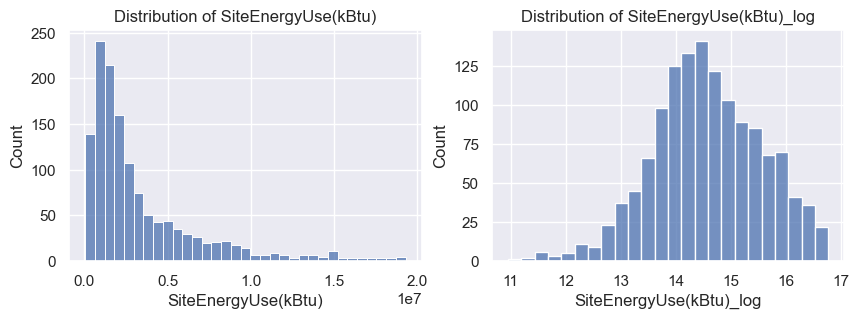

```python
building_df_clean['SiteEnergyUse(kBtu)_log'] = np.log(1+building_df_clean['SiteEnergyUse(kBtu)'])
print ('Skewness value for SiteEnergyUse before and after log transformation equal to {} and {} respectively.'
       .format(st.skew(building_df_clean['SiteEnergyUse(kBtu)']),
               st.skew(building_df_clean['SiteEnergyUse(kBtu)_log'])))

columns_toplot = ['SiteEnergyUse(kBtu)', 'SiteEnergyUse(kBtu)_log']
n_sub = len(columns_toplot)
n_col = 2
fig, axes = plt.subplots(int(round((0.49+n_sub/n_col), 0)),
                         n_col, figsize=(10, int(1.5*n_sub)))
axes = np.array(axes)
i = 0
for ax in axes.reshape(-1):
    sns.histplot(data=building_df_clean[columns_toplot[i]], ax=ax)
    ax.set_title('Distribution of {}'.format(columns_toplot[i]))
    i += 1
plt.show()
```

### B. Selecting all the columns that will be used for the iteration and train_test_split the data

```python
# Changing some columns type to object
building_df_clean[['ZipCode', 'PropertyUseTypeCount',
                   'BuildingDecade', 'EnergySourceCount']] = building_df_clean[['ZipCode', 'PropertyUseTypeCount',
                                                                                'BuildingDecade', 'EnergySourceCount']].astype(object)

# Creating a database with columns are not null
columns_list_target = ['SiteEnergyUse(kBtu)', 'SiteEnergyUse(kBtu)_log']
columns_list_data_1 = ['PropertyGFATotal', 'PropertyGFABuilding(s)',
                       'LargestPropertyUseTypeGFA', 'PrimaryPropertyType',
                       'ZipCode', 'NumberofFloors', 'BuildingType',
                       'PropertyUseTypeCount', 'BuildingDecade',
                       'BuildingAge', 'EnergySourceCount']
columns_list_data_2 = [column for column in building_df_clean.columns if column.endswith('_GFAratio')]
columns_list_data = columns_list_data_1 + columns_list_data_2
columns_list = columns_list_data + columns_list_target

data = building_df_clean[(building_df_clean[columns_list].notna()).all(axis=1)].reset_index(drop=True)
data = data[columns_list]

# Divide the data into 80% training and 20% testing
xtrain, xtest, ytrain, ytest = train_test_split(data[columns_list_data],
                                                data[columns_list_target],
                                                train_size=0.8, random_state=42)

# To keep the original index of the train and test data
train_index = xtrain.index
test_index = xtest.index

# Resetting index before the preprocessing
xtrain = xtrain.reset_index(drop=True)
xtest = xtest.reset_index(drop=True)
ytrain = ytrain.reset_index(drop=True)
ytest = ytest.reset_index(drop=True)
```

### C. Creating all possible combinations of columns in set 1 and set 2

- Set_1 combinations dictionary:

```python
# Creating all possible iteration of columns in set 1
set_1_columns_fix = ['PropertyGFATotal' , 'PrimaryPropertyType']
set_1_columns_to_iterate_on = ['PropertyGFABuilding(s)' , 'LargestPropertyUseTypeGFA' , 'ZipCode']

set_1_columns_iter_dict = {}
i = 0
for j in np.arange(0, len(set_1_columns_to_iterate_on) + 1):
    for k in list(combinations(set_1_columns_to_iterate_on,j)):
        set_1_columns_iter_dict['set_1_col_iter_{0}'.format(i)] = set_1_columns_fix + list(k)
        i += 1
```

- Set_2 combinations dictionary:

```python
# Creating all possible iteration of columns in set 2
set_2_columns_fix = ['PropertyGFATotal'] + [column for column in building_df_clean.columns if column.endswith('_GFAratio')]
set_2_columns_to_iterate_on = ['PropertyGFABuilding(s)', 'ZipCode']

set_2_columns_iter_dict = {}
i = 0
for j in np.arange(0, len(set_2_columns_to_iterate_on) + 1):
    for k in list(combinations(set_2_columns_to_iterate_on, j)):
        set_2_columns_iter_dict['set_2_col_iter_{0}'.format(i)] = set_2_columns_fix + list(k)
        i += 1
```

- Merging the two dictionaries:

```python
set_1_columns_iter_dict.update(set_2_columns_iter_dict)
```

Standardization before train_test_split can lead to data leakage. Thus, after train_test_split, we fit_transform the xtrain and transform the xtest for the standardization purpose. However, this also can lead to data leakage since we are using GridSearchCV on the xtrain data. To prevent this, We will assemble both the standardization and ML models in a pipeline then we use the pipeline as the estimator for GridSearchCV.

**Procedure:**

## 2. Performing the ML Models Test

```python
score = ('neg_mean_absolute_error', 'neg_root_mean_squared_error', 'r2')


# Function to calculate the Root Mean Square Percentage Error
# source : https://stackoverflow.com/questions/53165807/how-to-calculate-rmspe-in-python-using-numpy
def RMPSE(y_true, y_pred):

    # compute Root Mean Square Percentage Error between two arrays.
    loss = np.sqrt(np.mean(np.square(((y_true - y_pred) / y_true))))

    return loss


# Function that pick the best rank between 'neg_mean_absolute_error', 'neg_root_mean_squared_error', and 'r2' according to the fastest training time between them
def refit_strategy(cv_results):
    cv_results_ = pd.DataFrame(cv_results)

    # selecting the param best score using the different scoring method
    best_score_cv_results = cv_results_[(cv_results_['rank_test_neg_mean_absolute_error'] == 1)
                                        | (cv_results_['rank_test_neg_root_mean_squared_error'] == 1)
                                        | (cv_results_['rank_test_r2'] == 1)]

    # selecting the fastest mean_fit_time
    best_score_time_cv_results_index = best_score_cv_results['mean_fit_time'].idxmin()
    columns_list = ['mean_fit_time', 'std_fit_time', 'params',
                    'mean_test_neg_mean_absolute_error', 'std_test_neg_mean_absolute_error',
                    'mean_test_neg_root_mean_squared_error', 'std_test_neg_root_mean_squared_error',
                    'mean_test_r2', 'std_test_r2',]

    return(best_score_time_cv_results_index)


# Function that tranform grid.cv_results_ into dataframe
def resultize(grid):
    res = grid.cv_results_
    res = pd.DataFrame(res)
    cols = [i for i in res.columns if 'split' not in i]
    res = res[cols]
    res = res.sort_values('rank_test_r2')

    return res


# Function to find optimal param with grid search
def grid_search(model, param_grid, cv, scoring, refit, xtrain, ytrain):

    # we initiate the GridSearchCV
    grid = GridSearchCV(model, param_grid, cv=cv, scoring=scoring,
                        verbose=1, return_train_score=True,
                        refit=refit, n_jobs=-1)
    start = time.time()

    # we fit the GridSearchCV
    grid.fit(xtrain, ytrain)
    stop = time.time()

    return grid.best_params_


# Apply the best param obtained from the grid on the model
def estimator_model(estimator, xtrain, ytrain, xtest, ytest):
    start = time.time()

    # we fit the model
    estimator.fit(xtrain, ytrain)
    stop = time.time()

    # we test the train and test accuracy to check overfitting
    train_accuracy = estimator.score(xtrain, ytrain)
    test_accuracy = estimator.score(xtest, ytest)

    # we calcultae ypred to be compared with ytest
    ypred = estimator.predict(xtest)

    # we calcultate the errors and score of the model
    error_MAE = mean_absolute_error(ytest, ypred)
    error_MAPE = mean_absolute_percentage_error(ytest, ypred)
    error_RMSE = np.sqrt(mean_squared_error(ytest, ypred))
    error_RMPSE = RMPSE(ytest, ypred)
    score_r2 = r2_score(ytest, ypred)
    training_time = stop - start

    return train_accuracy, test_accuracy, ypred, error_MAE, error_MAPE, error_RMSE, error_RMPSE, score_r2, training_time
```

### A. Iteration and testing

Procedure:

- 1st, we loop on the two targets (with and without log transformation)
- 2nd, we loop on all selected columns combinations
- 3rd, we loop on the scalers for the numerical columns in xtrain and xtest (MinMax, Standard, Robust, and PowerTransformer)
- 4th, preprocessor, we pipeline together the scaler for the numerical columns and the OneHotEncoder for the categorical columns
- 5th, we loop on the models and its grid parameters
- 6th, we pipeline the preprocessor with the model and perform GridSearchCV in order to find the best parmaters for the model
- 7th, we apply the best parameters found by GridSearchCV on the model using xtrain and ytrain and test it on xtest and ytest
- 8th, we record into dataset the columns tested, target, model, best parameters, and scaler, as well as the errors, score, and training time obtained comparing ypred with ytest
- Finally we select the best score from all the iterations and extract the informations

```python
# We create dataframe to store the error and score values of the models
ML_results_df = pd.DataFrame(columns = ['DataSetName', 'DataSetCols', 'Target',
                                        'Scaler', 'Model', 'BestParams'])

# Loop on the target with and without log transformation
for target_col in ['SiteEnergyUse(kBtu)', 'SiteEnergyUse(kBtu)_log']:
    # loop on the columns set
    for set_columns_list in set_1_columns_iter_dict:
        # we select the colomns in xtrain and ytrain
        xtrain_select = xtrain[set_1_columns_iter_dict[set_columns_list]]
        xtest_select = xtest[set_1_columns_iter_dict[set_columns_list]]
        ytrain_select = ytrain[target_col]
        ytest_select = ytest[target_col]

        # we divide the colomn into numerical colomn and categorical columns
        num_features = [col for col in xtrain_select.columns if not ((xtrain_select[col].dtype == 'object')
                                                                     | (col.endswith('_GFAratio')))]
        cat_features = [col for col in xtrain_select.columns if xtrain_select[col].dtype == 'object']

        # loop on the scaler
        for scaler in [('MinMaxScaler', MinMaxScaler()), ('StandardScaler', StandardScaler()),
                       ('RobustScaler', RobustScaler()), ('PowerTransformer', PowerTransformer())]:

            # maps the transformers to the relevant columns
            num_pipe = make_pipeline(scaler[1])
            cat_pipe = make_pipeline(OneHotEncoder(sparse_output=False, handle_unknown='ignore', dtype=np.int32))
            preprocessor = ColumnTransformer(transformers=[('scale', num_pipe, num_features),
                                                           ('oh_encode', cat_pipe, cat_features),
                                                          ], remainder='passthrough', verbose_feature_names_out=False)
            preprocessor.set_output(transform='pandas')

            # loop on the ML models
            for model_name, grid_params in [[('LinearRegression', LinearRegression()), {'LinearRegression__fit_intercept':(True, False)}],
                                            [('ElasticNet', ElasticNet()), {'ElasticNet__alpha':np.logspace(-3, 0, 4),
                                                                            'ElasticNet__l1_ratio':np.around(np.arange(0., 1.01, 0.1),2),
                                                                            'ElasticNet__tol':np.logspace(-4, 0, 5)}],
                                            [('KernelRidge', KernelRidge()), {'KernelRidge__kernel':['poly', 'rbf'],
                                                                              'KernelRidge__alpha':np.logspace(-3, 1, 5),
                                                                              'KernelRidge__gamma':np.logspace(-3, 0, 4)}],
                                            [('KNeighborsRegressor', KNeighborsRegressor()), {'KNeighborsRegressor__n_neighbors':np.arange(2, 21, 1),
                                                                                              'KNeighborsRegressor__weights':('uniform', 'distance')}],
                                            [('RandomForestRegressor', RandomForestRegressor()), {'RandomForestRegressor__n_estimators':[10,50,100,200,500],
                                                                                                  'RandomForestRegressor__min_samples_split':np.arange(2, 11, 2),
                                                                                                 }],
                                            [('XGBRegressor', XGBRegressor()), {'XGBRegressor__n_estimators':[25, 50, 75, 100],
                                                                                'XGBRegressor__max_depth':[2, 4, 6]}]
                                           ]:
                # find optimal param with grid search
                estimator = Pipeline(steps=[('preprocessor', preprocessor), model_name])

                best_params = grid_search(estimator, grid_params, 5, score, refit_strategy, xtrain_select, ytrain_select)

                # apply the best param obtained from the grid on the model
                estimator = Pipeline(steps=[('preprocessor', preprocessor), model_name])
                estimator.set_params(**best_params)
                train_accuracy, test_accuracy, ypred_select, error_MAE, error_MAPE, error_RMSE, error_RMPSE, score_r2, training_time = estimator_model(estimator, xtrain_select, ytrain_select, xtest_select, ytest_select)

                #storing the regressor results in df
                regressor_results_df = pd.DataFrame()
                df = pd.DataFrame(np.array([train_accuracy, test_accuracy, error_MAE, error_MAPE, error_RMSE, error_RMPSE, score_r2, training_time])).T
                regressor_results_df[['train_accuracy', 'test_accuracy', 'error_MAE', 'error_MAPE', 'error_RMSE', 'error_RMPSE', 'score_r2', 'training_time (s)']] = df
                regressor_results_df['BestParams'] = str(best_params)
                regressor_results_df['DataSetName'] = set_columns_list
                regressor_results_df['DataSetCols'] = str(set_1_columns_iter_dict[set_columns_list])
                regressor_results_df['Target'] = target_col
                regressor_results_df['Model'] = model_name[0]
                regressor_results_df['Scaler'] = scaler[0]

                ML_results_df = pd.concat([ML_results_df, regressor_results_df], ignore_index=True)
```

[output not shown]

[output cut: 253 more lines]

[output not shown]

[output not shown]

[output not shown]

[output not shown]

[output not shown]

[output not shown]

[output not shown]

[output not shown]

[output not shown]

[output not shown]

[output not shown]

[output not shown]

[output cut: 117 more lines]

[output not shown]

### B. Analysis of the tested models

```python
ML_results_df.sort_values('score_r2', ascending=False).head(5)
```

|  | DataSetName | DataSetCols | Target | Scaler | Model | BestParams | train_accuracy | test_accuracy | error_MAE | error_MAPE | error_RMSE | error_RMPSE | score_r2 | training_time (s) |
| --- | --- | --- | --- | --- | --- | --- | --- | --- | --- | --- | --- | --- | --- | --- |
| 218 | set_2_col_iter_1 | ['PropertyGFATotal', 'Bank Branch_GFAratio', '... | SiteEnergyUse(kBtu) | MinMaxScaler | KernelRidge | {'KernelRidge__alpha': 0.01, 'KernelRidge__gam... | 0.706976 | 0.712005 | 1.236208e+06 | 0.725561 | 1.948283e+06 | 1.730457 | 0.712005 | 0.046130 |
| 98 | set_1_col_iter_4 | ['PropertyGFATotal', 'PrimaryPropertyType', 'P... | SiteEnergyUse(kBtu) | MinMaxScaler | KernelRidge | {'KernelRidge__alpha': 0.1, 'KernelRidge__gamm... | 0.663631 | 0.711281 | 1.254423e+06 | 0.821219 | 1.950733e+06 | 2.057754 | 0.711281 | 0.040219 |
| 200 | set_2_col_iter_0 | ['PropertyGFATotal', 'Bank Branch_GFAratio', '... | SiteEnergyUse(kBtu) | StandardScaler | KernelRidge | {'KernelRidge__alpha': 0.001, 'KernelRidge__ga... | 0.700457 | 0.706741 | 1.234541e+06 | 0.737606 | 1.966009e+06 | 1.752846 | 0.706741 | 0.041642 |
| 176 | set_1_col_iter_7 | ['PropertyGFATotal', 'PrimaryPropertyType', 'P... | SiteEnergyUse(kBtu) | StandardScaler | KernelRidge | {'KernelRidge__alpha': 0.01, 'KernelRidge__gam... | 0.726631 | 0.705839 | 1.248206e+06 | 0.839702 | 1.969031e+06 | 2.096884 | 0.705839 | 0.051245 |
| 110 | set_1_col_iter_4 | ['PropertyGFATotal', 'PrimaryPropertyType', 'P... | SiteEnergyUse(kBtu) | RobustScaler | KernelRidge | {'KernelRidge__alpha': 0.01, 'KernelRidge__gam... | 0.687133 | 0.705062 | 1.221255e+06 | 0.784045 | 1.971627e+06 | 1.987908 | 0.705062 | 0.047338 |

#### a) Best test

```python
# Selecting the the best model informations
best_model_index = ML_results_df['score_r2'].idxmax()
Data_Set_Name = ML_results_df.loc[best_model_index, 'DataSetName']

ML_results_df.iloc[best_model_index]
```

```
DataSetName                                           set_2_col_iter_1
DataSetCols          ['PropertyGFATotal', 'Bank Branch_GFAratio', '...
Target                                             SiteEnergyUse(kBtu)
Scaler                                                    MinMaxScaler
Model                                                      KernelRidge
BestParams           {'KernelRidge__alpha': 0.01, 'KernelRidge__gam...
train_accuracy                                                0.706976
test_accuracy                                                 0.712005
error_MAE                                               1236207.763769
error_MAPE                                                    0.725561
error_RMSE                                              1948282.647159
error_RMPSE                                                   1.730457
score_r2                                                      0.712005
training_time (s)                                              0.04613
Name: 218, dtype: object
```

According to the overfitting test, the train and test accuracy give almost similar score which indicate that we have very low overfitting problem.

```python
best_model_name = ML_results_df.loc[best_model_index, 'Model']
best_grid_params = ML_results_df.loc[best_model_index, 'BestParams']
print('The best parameters from the model', best_grid_params)
best_scaler = ML_results_df.loc[best_model_index, 'Scaler']

# preparing xtrain and ytrain
xtrain_select_columns = eval(ML_results_df.loc[best_model_index, 'DataSetCols'])
ytrain_select_column = ML_results_df.loc[best_model_index, 'Target']
xtrain_select = xtrain[xtrain_select_columns]
xtest_select = xtest[xtrain_select_columns]
ytrain_select = ytrain[ytrain_select_column]
ytest_select = ytest[ytrain_select_column]
print('')
print('Columns list used by the model for the prediction:', xtrain_select_columns)
```

[output not shown]

#### b) Score analysis

- Effect of the scalers for the numerical columns in xtrain and xtest:

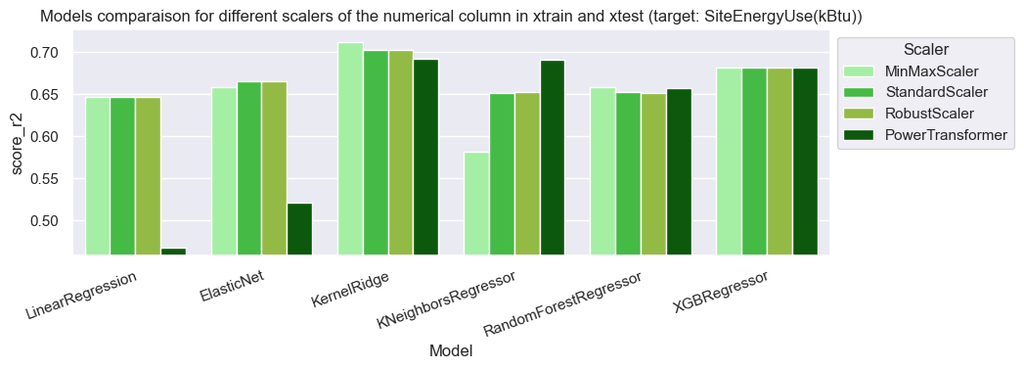

```python
Data_Set_Name = ML_results_df.loc[best_model_index, 'DataSetName']
ytrain_select_column = ML_results_df.loc[best_model_index, 'Target']

condition = ((ML_results_df['DataSetName'] == Data_Set_Name)
             & (ML_results_df['Target'] == ytrain_select_column))

plt.figure(figsize=(10, 3))
ax = sns.barplot(x=ML_results_df[condition]['Model'],
                 y=ML_results_df[condition]['score_r2'],
                 hue=ML_results_df['Scaler'],
                 palette=['palegreen', 'limegreen',
                          'yellowgreen', 'darkgreen'])
sns.move_legend(ax, 'upper left', bbox_to_anchor=(1, 1))
plt.title('Models comparaison for different scalers of the numerical column in xtrain and xtest (target: {})'
          .format(ytrain_select_column))
plt.xticks(ha='right', rotation=20, rotation_mode='anchor')
plt.ylim([ML_results_df[condition]['score_r2'].min()*0.98,
          ML_results_df[condition]['score_r2'].max()*1.02])
plt.show()
```

For LinearRegression, and ElasticNet, PowerTransformer give very low score than the other scalers. For XGBoost, all 4 scalers give the same score. For KNN, Powertransformer give better score comparing to the other scaler.

For the best model **KernelRidge**, we got the **highest score** for all 4 scalers by comparaison to the other models. The best scaler for KernelRidge is **MinMaxScaler**.

- Effect of log transforming the target:

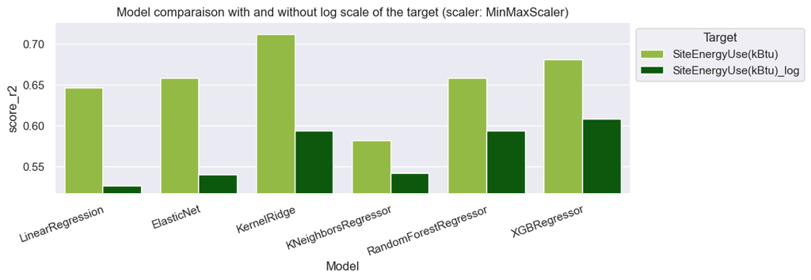

```python
best_scaler = ML_results_df.loc[best_model_index, 'Scaler']

condition = ((ML_results_df['DataSetName'] == Data_Set_Name)
             & (ML_results_df['Scaler'] == best_scaler))

plt.figure(figsize=(10, 3))
ax = sns.barplot(x=ML_results_df[condition]['Model'],
                 y=ML_results_df[condition]['score_r2'],
                 hue=ML_results_df['Target'],
                 palette=['yellowgreen', 'darkgreen'])
sns.move_legend(ax, 'upper left', bbox_to_anchor=(1, 1))
plt.title('Model comparaison with and without log scale of the target (scaler: {})'
          .format(best_scaler))
plt.xticks(ha='right', rotation=20, rotation_mode='anchor')
plt.ylim([ML_results_df[condition]['score_r2'].min()*0.98,
          ML_results_df[condition]['score_r2'].max()*1.02])
plt.show()
```

**Without Log scaling the target**, we got better score for all models with KernelRidge as the best with a score above 0.70.

#### c) Training time analysis

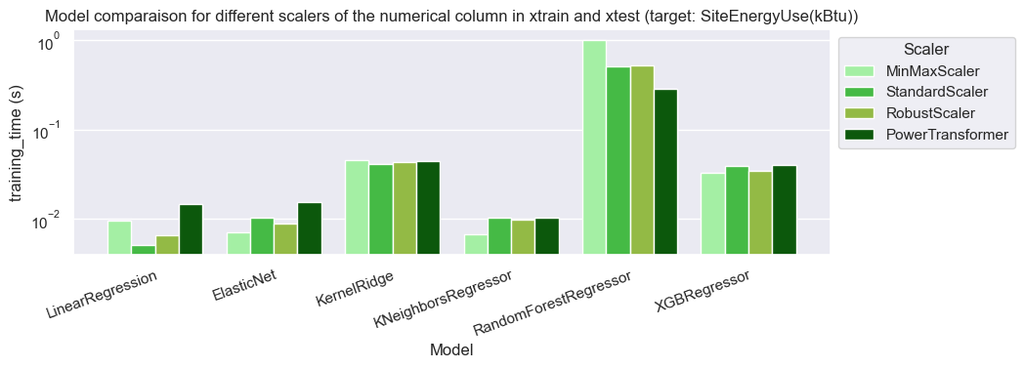

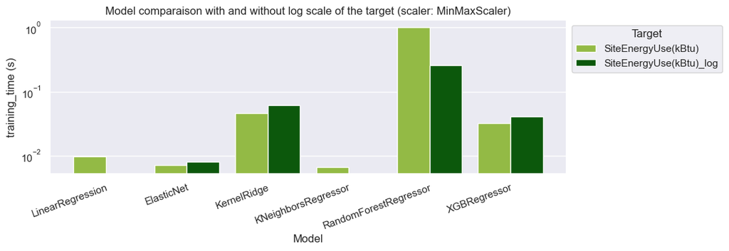

```python
ytrain_select_column = ML_results_df.loc[best_model_index, 'Target']

condition = ((ML_results_df['DataSetName'] == Data_Set_Name)
             & (ML_results_df['Target'] == ytrain_select_column))

plt.figure(figsize=(10, 3))
ax = sns.barplot(x=ML_results_df[condition]['Model'],
                 y=ML_results_df[condition]['training_time (s)'],
                 hue=ML_results_df['Scaler'],
                 palette=['palegreen', 'limegreen',
                          'yellowgreen', 'darkgreen'])
sns.move_legend(ax, 'upper left', bbox_to_anchor=(1, 1))
plt.title('Model comparaison for different scalers of the numerical column in xtrain and xtest (target: {})'
          .format(ytrain_select_column))
plt.xticks(ha='right', rotation=20, rotation_mode='anchor')
plt.semilogy()
plt.show()

ytrain_select_column = ML_results_df.loc[best_model_index, 'Target']

condition = ((ML_results_df['DataSetName'] == Data_Set_Name)
             & (ML_results_df['Scaler'] == best_scaler))

plt.figure(figsize=(10, 3))
ax = sns.barplot(x=ML_results_df[condition]['Model'],
                 y=ML_results_df[condition]['training_time (s)'],
                 hue=ML_results_df['Target'],
                 palette=['yellowgreen', 'darkgreen'])
sns.move_legend(ax, 'upper left', bbox_to_anchor=(1, 1))
plt.title('Model comparaison with and without log scale of the target (scaler: {})'
          .format(best_scaler))
plt.xticks(ha='right', rotation=20, rotation_mode='anchor')
plt.semilogy()
plt.show()
```

#### d) Errors and score of each model

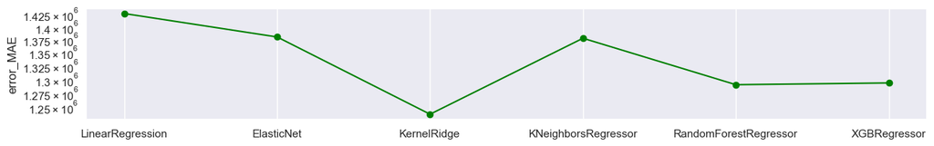

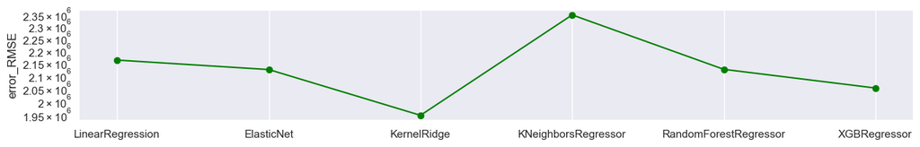

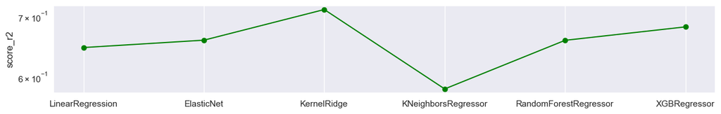

[figure not shown]

```python
condition = ((ML_results_df['DataSetName'] == Data_Set_Name)
             & (ML_results_df['Target'] == ytrain_select_column)
             & (ML_results_df['Scaler'] == best_scaler))

plt.figure(figsize=(15, 2))
plt.plot(ML_results_df[condition]['Model'].unique(),
         ML_results_df[condition]['error_MAE'],
         c='green', marker='o', markerfacecolor='green')
plt.ylabel('error_MAE')
plt.semilogy()
plt.show()

plt.figure(figsize=(15, 2))
plt.plot(ML_results_df[condition]['Model'].unique(),
         ML_results_df[condition]['error_RMSE'],
         c='green', marker='o', markerfacecolor='green')
plt.ylabel('error_RMSE')
plt.semilogy()
plt.show()

plt.figure(figsize=(15, 2))
plt.plot(ML_results_df[condition]['Model'].unique(),
         ML_results_df[condition]['score_r2'],
         c='green', marker='o', markerfacecolor='green')
plt.ylabel('score_r2')
plt.semilogy()
plt.show()

plt.figure(figsize=(15, 2))
plt.plot(ML_results_df[condition]['Model'].unique(),
         ML_results_df[condition]['training_time (s)'],
         c='green', marker='o', markerfacecolor='green')
plt.ylabel('training_time (s)')
plt.semilogy()
plt.show()
```

Between all 6 models, **KernelRidge** has the **lowest errors and the best score**.

### C. Selecting the best model and best parameters to perform the final tests on few additional columns

#### a) Dummy models on the target

- Random value generation between min and max of the target
- Dummy regressor based on mean value of the target
- Dummy regressor based on median value of the target

```python
# Random distribution model, value betwen min and max of the target
start = time.time()
ypred_select = np.random.randint(np.min(ytrain_select), np.max(ytrain_select), ytest_select.shape)
stop = time.time()
print('MAE =', mean_absolute_error(ytest_select, ypred_select))
print('MAPE =', mean_absolute_percentage_error(ytest_select, ypred_select))
print('RMSE =', np.sqrt(mean_squared_error(ytest_select, ypred_select)))
print('RMPSE =', RMPSE(ytest_select, ypred_select))
print('Score R2 =', r2_score(ytest_select, ypred_select))
print(f'Training time = {stop - start} s')
```

```
MAE = 7466460.676648105
MAPE = 9.27542578919131
RMSE = 9108439.254289273
RMPSE = 26.71594867527577
Score R2 = -5.294604762123123
Training time = 0.0 s
```

```python
# Mean distribution model
dum = dummy.DummyRegressor(strategy='mean')
start = time.time()
dum.fit(xtrain_select, ytrain_select)
stop = time.time()
ypred_select = dum.predict(xtest_select)
print('MAE =', mean_absolute_error(ytest_select, ypred_select))
print('MAPE =', mean_absolute_percentage_error(ytest_select, ypred_select))
print('RMSE =', np.sqrt(mean_squared_error(ytest_select, ypred_select)))
print('RMPSE =', RMPSE(ytest_select, ypred_select))
print('Score R2 =', r2_score(ytest_select, ypred_select))
print(f'Training time = {stop - start} s')
```

```
MAE = 2532850.6247793315
MAPE = 2.41857602260493
RMSE = 3632047.8458499387
RMPSE = 6.158973883988778
Score R2 = -0.0008837892879551834
Training time = 0.0 s
```

```python
# Median distribution model
dum = dummy.DummyRegressor(strategy='median')
start = time.time()
dum.fit(xtrain_select, ytrain_select)
stop = time.time()
ypred_select = dum.predict(xtest_select)
print('MAE =', mean_absolute_error(ytest_select, ypred_select))
print('MAPE =', mean_absolute_percentage_error(ytest_select, ypred_select))
print('RMSE =', np.sqrt(mean_squared_error(ytest_select, ypred_select)))
print('RMPSE =', RMPSE(ytest_select, ypred_select))
print('Score R2 =', r2_score(ytest_select, ypred_select))
print(f'Training time = {stop - start} s')
```

```
MAE = 2316592.115135539
MAPE = 1.3798386220668668
RMSE = 3923622.298656515
RMPSE = 3.516249686656798
Score R2 = -0.1680324851511643
Training time = 0.001001119613647461 s
```

- Between the random generation, mean, and median dummy regressor, mean is the best with a r2 score of 0 and lower RMSE but higher MAE than the median dummy regressor.
- By comparaison with the best model here, KernelRidge, we see lot lower MAE and RMSE and lot higher r2 score compared to dummy models.

#### b) Perform tests on few additional columns using the best model

```python
additional_cols = ['NumberofFloors', 'BuildingType', 'PropertyUseTypeCount',
                   'BuildingDecade', 'BuildingAge', 'EnergySourceCount']

columns_iter_dict = {}
i = 0
for j in np.arange(0, len(additional_cols) + 1):
    for k in list(combinations(additional_cols, j)):
        columns_iter_dict['col_iter_{0}'.format(i)] = xtrain_select_columns + list(k)
        i += 1
```

```python
# We create dataframe to store the error and score values of the models
ML_results_df_additional = pd.DataFrame(columns=['DataSetName', 'DataSetCols', 'Target',
                                                 'Scaler', 'Model', 'BestParams'])

# Loop on the columns set
for set_columns_list in columns_iter_dict:
    # we select the colomns in xtrain and ytrain
    xtrain_select = xtrain[columns_iter_dict[set_columns_list]]
    xtest_select = xtest[columns_iter_dict[set_columns_list]]
    ytrain_select = ytrain[ytrain_select_column]
    ytest_select = ytest[ytrain_select_column]

    # we divide the colomn into numerical colomn and categorical columns
    num_features = [col for col in xtrain_select.columns if not ((xtrain_select[col].dtype == 'object')
                                                                 | (col.endswith('_GFAratio')))]
    cat_features = [col for col in xtrain_select.columns if xtrain_select[col].dtype == 'object']

    # maps the transformers to the relevant columns
    num_pipe = make_pipeline(eval(best_scaler)())
    cat_pipe = make_pipeline(OneHotEncoder(sparse_output=False, handle_unknown='ignore',
                                           dtype=np.int32))
    preprocessor = ColumnTransformer(transformers=[('scale', num_pipe, num_features),
                                                   ('oh_encode', cat_pipe, cat_features)],
                                     remainder='passthrough', verbose_feature_names_out=False)
    preprocessor.set_output(transform='pandas')

    # Apply the best param obtained from the grid on the model
    estimator = Pipeline(steps=[('preprocessor', preprocessor),
                                (best_model_name, eval(best_model_name)())])
    estimator.set_params(**eval(best_grid_params))
    train_accuracy, test_accuracy, ypred_select, error_MAE, error_MAPE, error_RMSE, error_RMPSE, score_r2, training_time = estimator_model(estimator, xtrain_select, ytrain_select, xtest_select, ytest_select)

    # Storing the regressor results in df
    regressor_results_df = pd.DataFrame()
    df = pd.DataFrame(np.array([train_accuracy, test_accuracy,
                                error_MAE, error_MAPE, error_RMSE,
                                error_RMPSE, score_r2, training_time])).T
    regressor_results_df[['train_accuracy', 'test_accuracy',
                          'error_MAE', 'error_MAPE', 'error_RMSE',
                          'error_RMPSE', 'score_r2', 'training_time (s)']] = df
    regressor_results_df['BestParams'] = best_grid_params
    regressor_results_df['DataSetName'] = set_columns_list
    regressor_results_df['DataSetCols'] = str(columns_iter_dict[set_columns_list])
    regressor_results_df['Target'] = ytrain_select_column
    regressor_results_df['Model'] = best_model_name
    regressor_results_df['Scaler'] = best_scaler

    ML_results_df_additional = pd.concat([ML_results_df_additional, regressor_results_df],
                                         ignore_index=True)
```

```python
ML_results_df_additional.sort_values('score_r2', ascending=False).head(5)[['DataSetName', 'Target',
                                                                           'Scaler', 'Model', 'error_MAE',
                                                                           'error_MAPE', 'error_RMSE',
                                                                           'error_RMPSE', 'train_accuracy',
                                                                           'score_r2', 'training_time (s)']]
```

|  | DataSetName | Target | Scaler | Model | error_MAE | error_MAPE | error_RMSE | error_RMPSE | train_accuracy | score_r2 | training_time (s) |
| --- | --- | --- | --- | --- | --- | --- | --- | --- | --- | --- | --- |
| 5 | col_iter_5 | SiteEnergyUse(kBtu) | MinMaxScaler | KernelRidge | 1.226314e+06 | 0.704886 | 1.918300e+06 | 1.687763 | 0.721807 | 0.720801 | 0.036000 |
| 10 | col_iter_10 | SiteEnergyUse(kBtu) | MinMaxScaler | KernelRidge | 1.225944e+06 | 0.702346 | 1.923035e+06 | 1.684985 | 0.726552 | 0.719421 | 0.038999 |
| 31 | col_iter_31 | SiteEnergyUse(kBtu) | MinMaxScaler | KernelRidge | 1.226999e+06 | 0.665203 | 1.940374e+06 | 1.578207 | 0.752455 | 0.714339 | 0.038000 |
| 21 | col_iter_21 | SiteEnergyUse(kBtu) | MinMaxScaler | KernelRidge | 1.228767e+06 | 0.672342 | 1.941692e+06 | 1.606910 | 0.746107 | 0.713951 | 0.038000 |
| 0 | col_iter_0 | SiteEnergyUse(kBtu) | MinMaxScaler | KernelRidge | 1.236208e+06 | 0.725561 | 1.948283e+06 | 1.730457 | 0.706976 | 0.712005 | 0.039994 |

```python
# Selecting the the best model informations
best_model_index = ML_results_df_additional['score_r2'].idxmax()
print('Columns list used by the model for the prediction:',
      ML_results_df_additional.loc[best_model_index, 'DataSetCols'])
```

```
Columns list used by the model for the prediction: ['PropertyGFATotal', 'Bank Branch_GFAratio', 'College/University_GFAratio', 'Data Center_GFAratio', 'Distribution Center_GFAratio', 'Fitness Center/Health Club/Gym_GFAratio', 'K-12 School_GFAratio', 'Manufacturing/Industrial Plant_GFAratio', 'Medica…
```

Adding BuildingAge give better score and lower errors MAE and RMSE on the prediction. We will add Building Age to model prediction of SiteEnergyUse.

##### i) Predicted versus real value of the target

```python
# Preparing xtrain and ytrain
xtrain_select_columns = eval(ML_results_df_additional.loc[best_model_index, 'DataSetCols'])
ytrain_select_column = ML_results_df_additional.loc[best_model_index, 'Target']
xtrain_select = xtrain[xtrain_select_columns]
xtest_select = xtest[xtrain_select_columns]
ytrain_select = ytrain[ytrain_select_column]
ytest_select = ytest[ytrain_select_column]
```

```python
# Separating numerical features for scaling from categorical feature for OneHotEncoding
num_features = [col for col in xtrain_select.columns if not ((xtrain_select[col].dtype == 'object')
                                                             | (col.endswith('_GFAratio')))]
cat_features = [col for col in xtrain_select.columns if xtrain_select[col].dtype == 'object']
```

```python
# Maps the transformers to the relevant columns
num_pipe = make_pipeline(eval(best_scaler)())
cat_pipe = make_pipeline(OneHotEncoder(sparse_output=False, handle_unknown='ignore', dtype=np.int32))
preprocessor = ColumnTransformer(transformers=[('scale', num_pipe, num_features),
                                               ('oh_encode', cat_pipe, cat_features)],
                                 remainder='passthrough', verbose_feature_names_out=False)
preprocessor.set_output(transform='pandas')
```

```
ColumnTransformer(remainder='passthrough',
                  transformers=[('scale',
                                 Pipeline(steps=[('minmaxscaler',
                                                  MinMaxScaler())]),
                                 ['PropertyGFATotal', 'PropertyGFABuilding(s)',
                                  'BuildingAge']),
                                ('oh_encode',
                                 Pipeline(steps=[('onehotencoder',
                                                  OneHotEncoder(dtype=<class 'numpy.int32'>,
                                                                handle_unknown='ignore',
                                                                sparse_output=False))]),
                                 [])],
                  verbose_feature_names_out=False)
```

```python
# Apply the grid param on the best model
estimator = Pipeline(steps=[('preprocessor', preprocessor),
                            (best_model_name, eval(best_model_name)())])
estimator.set_params(**eval(best_grid_params))
train_accuracy, test_accuracy, ypred_select, error_MAE, error_MAPE, error_RMSE, error_RMPSE, score_r2, training_time = estimator_model(estimator, xtrain_select, ytrain_select, xtest_select, ytest_select)

print('Model {} with parameters {}.'.format(best_model_name, best_grid_params))
print('  X columns: {}.'.format(xtrain_select.columns))
print('  Y column: {}.'.format(ytrain_select_column))
print()
print('       MAE =', error_MAE)
print('       MAPE =', error_MAPE)
print('       RMSE =', error_RMSE)
print('       RMPSE =', error_RMPSE)
print('       Score R2 =', score_r2)
print('       Training time =', training_time)
print()
print('Overfitting check:')
print('       train_accuracy =', train_accuracy)
print('       test_accuracy =', test_accuracy)
```

```
Model KernelRidge with parameters {'KernelRidge__alpha': 0.01, 'KernelRidge__gamma': 0.1, 'KernelRidge__kernel': 'rbf'}.
  X columns: Index(['PropertyGFATotal', 'Bank Branch_GFAratio',
       'College/University_GFAratio', 'Data Center_GFAratio',
       'Distribution Center_GFAratio',
       'Fitness Center/Health Club/Gym_GFAratio', 'K-12 School_GFAratio',
       'Manufacturing/Industrial Plant_GFAratio', 'Medical Office_GFAratio',
       'Mixed Use Property_GFAratio', 'Multifamily Housing_GFAratio',
       'Non-Refrigerated Warehouse_GFAratio', 'Office_GFAratio',
       'Other_GFAratio', 'Other - Entertainment/Public Assembly_GFAratio',
       'Other - Recreation_GFAratio', 'Other - Services_GFAratio',
       'Parking_GFAratio', 'Refrigerated Warehouse_GFAratio',
       'Repair Services (Vehicle, Shoe, Locksmith, etc)_GFAratio',
       'Restaurant_GFAratio', 'Retail Store_GFAratio',
       'Self-Storage Facility_GFAratio', 'Senior Care Community_GFAratio',
       'Social/Meeting Hall_GFAratio', 'Supermarket/Grocery Store_GFAratio',
       'Worship Facility_GFAratio', 'PropertyGFABuilding(s)', 'BuildingAge'],
      dtype='object').
  Y column: SiteEnergyUse(kBtu).

       MAE = 1226313.6029306105
       MAPE = 0.7048859658063289
       RMSE = 1918300.0600254314
       RMPSE = 1.6877626914060102
       Score R2 = 0.7208011570487323
       Training time = 0.040999412536621094

Overfitting check:
       train_accuracy = 0.7218069102380434
       test_accuracy = 0.7208011570487323
```

The train and test accuracy are almost similar which means that we have low overfitting.

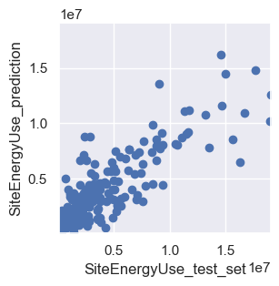

```python
# Comparison between ypred and ytest
plt.figure(figsize=(3, 3))
plt.plot(ytest_select,ypred_select, 'o')
plt.xlabel('SiteEnergyUse_test_set')
plt.xlim([min([ytest_select.min(), ypred_select.min()]), max([ytest_select.max(), ypred_select.max()])])
plt.ylabel('SiteEnergyUse_prediction')
plt.ylim([min([ytest_select.min(), ypred_select.min()]), max([ytest_select.max(), ypred_select.max()])])
plt.show()
```

From the scatter plot, the prediction starts to become less accurate for SiteEnergyUsage higher than 1e7 kBtu.

##### ii) Features importance

- Computing the permutation importances on the test set

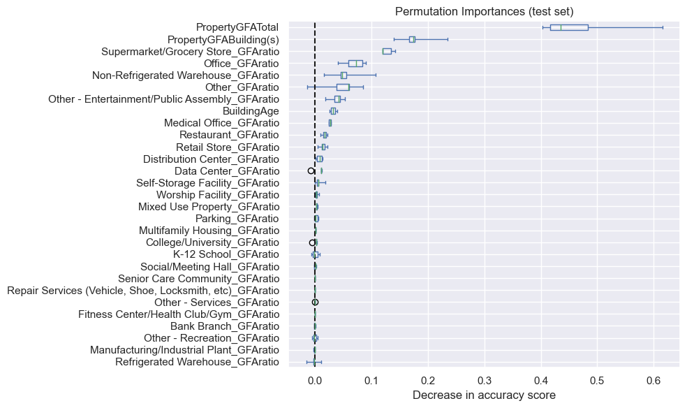

```python
# Fit the model
estimator.fit(xtrain_select, ytrain_select)
# Perform permutation importance
result = permutation_importance(estimator, xtest_select, ytest_select,
                                n_repeats=5, random_state=42, n_jobs=-1)

# Get importance
sorted_importances_idx = result.importances_mean.argsort()
importances = pd.DataFrame(result.importances[sorted_importances_idx].T,
                           columns=xtrain_select.columns[sorted_importances_idx])

ax = importances.plot.box(vert=False, whis=10, figsize=(10, 6))
ax.set_title('Permutation Importances (test set)')
ax.axvline(x=0, color='k', linestyle='--')
ax.set_xlabel('Decrease in accuracy score')
ax.figure.tight_layout()
```

- Computing the permutation importances on the training set:

To be compared with the test set to check again for overfitting.

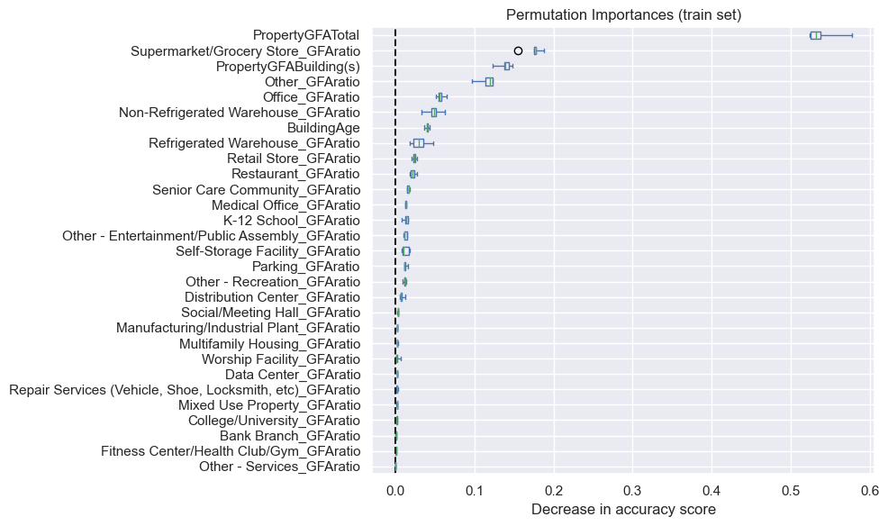

```python
# Perform permutation importance
result = permutation_importance(estimator, xtrain_select, ytrain_select,
                                n_repeats=5, random_state=42, n_jobs=-1)

# Get importance
sorted_importances_idx = result.importances_mean.argsort()
importances = pd.DataFrame(result.importances[sorted_importances_idx].T,
                           columns=xtrain_select.columns[sorted_importances_idx])

ax = importances.plot.box(vert=False, whis=10, figsize=(10, 6))
ax.set_title('Permutation Importances (train set)')
ax.axvline(x=0, color='k', linestyle='--')
ax.set_xlabel('Decrease in accuracy score')
ax.figure.tight_layout()
```

- PropertyGFATotal is the main feature for the model prediction of SiteEnergyUse.
- Top 3 features are identical in both train and test set (low overfitting).
- As the training time is low, we will not select the most important features but we will keep using all the features for the model prediction.

#### c) Perform a final test on 'ENERGYSTARScore' column

Since ENERGYSTARScore have missing values, we are going to do two tests on the same data where ENERGYSTARScore is filled.

```python
# Selecting the the best model informations
best_model_index = ML_results_df_additional['score_r2'].idxmax()
ML_results_df_additional.iloc[best_model_index]
```

```
DataSetName                                                 col_iter_5
DataSetCols          ['PropertyGFATotal', 'Bank Branch_GFAratio', '...
Target                                             SiteEnergyUse(kBtu)
Scaler                                                    MinMaxScaler
Model                                                      KernelRidge
BestParams           {'KernelRidge__alpha': 0.01, 'KernelRidge__gam...
train_accuracy                                                0.721807
test_accuracy                                                 0.720801
error_MAE                                               1226313.602931
error_MAPE                                                    0.704886
error_RMSE                                              1918300.060025
error_RMPSE                                                   1.687763
score_r2                                                      0.720801
training_time (s)                                                0.036
Name: 5, dtype: object
```

```python
# Selecting the columns of best model
xtrain_select_columns = eval(ML_results_df_additional.loc[best_model_index, 'DataSetCols'])
ytrain_select_column = ML_results_df_additional.loc[best_model_index, 'Target']

# Creating a database with columns are not null
columns_list_target = ytrain_select_column
columns_list_data = xtrain_select_columns + ['ENERGYSTARScore']
columns_list = [columns_list_target] + columns_list_data

data = building_df_clean[(building_df_clean[columns_list].notna()).all(axis=1)].reset_index(drop=True)
data = data[columns_list]

# Divide the data into 80% training and 20% testing
xtrain, xtest, ytrain, ytest = train_test_split(data[columns_list_data],
                                                data[columns_list_target],
                                                train_size=0.8, random_state=42)

# To keep the original index of the train and test data
train_index = xtrain.index
test_index = xtest.index

# Resetting index before the preprocessing
xtrain = xtrain.reset_index(drop=True)
xtest = xtest.reset_index(drop=True)
ytrain = ytrain.reset_index(drop=True)
ytest = ytest.reset_index(drop=True)
```

```python
# Permutation ON ENERGYSTARScore column
ENERGYSTARScore_col = ['ENERGYSTARScore']

columns_iter_dict = {}
i = 0
for j in np.arange(0, len(ENERGYSTARScore_col) + 1):
    for k in list(combinations(ENERGYSTARScore_col, j)):
        columns_iter_dict['col_iter_{0}'.format(i)] = xtrain_select_columns + list(k)
        i += 1
```

```python
# We create dataframe to store the error and score values of the models
ML_results_df_ENERGYSTARScore = pd.DataFrame(columns = ['DataSetName', 'DataSetCols',
                                                        'Target', 'Scaler',
                                                        'Model', 'BestParams'])

# Loop on the columns set
for set_columns_list in columns_iter_dict:
    # we select the colomns in xtrain and ytrain
    xtrain_select = xtrain[columns_iter_dict[set_columns_list]]
    xtest_select = xtest[columns_iter_dict[set_columns_list]]
    ytrain_select = ytrain
    ytest_select = ytest

    # we divide the colomn into numerical colomn and categorical columns
    num_features = [col for col in xtrain_select.columns if not ((xtrain_select[col].dtype == 'object')
                                                                 | (col.endswith('_GFAratio')))]
    cat_features = [col for col in xtrain_select.columns if xtrain_select[col].dtype == 'object']

    # maps the transformers to the relevant columns
    num_pipe = make_pipeline(eval(best_scaler)())
    cat_pipe = make_pipeline(OneHotEncoder(sparse_output=False, handle_unknown='ignore', dtype=np.int32))
    preprocessor = ColumnTransformer(transformers=[('scale', num_pipe, num_features),
                                                   ('oh_encode', cat_pipe, cat_features)],
                                     remainder='passthrough', verbose_feature_names_out=False)
    preprocessor.set_output(transform='pandas')

    # apply the best param obtained from the grid on the model
    estimator = Pipeline(steps=[('preprocessor', preprocessor),
                                (best_model_name, eval(best_model_name)())])
    estimator.set_params(**eval(best_grid_params))
    train_accuracy, test_accuracy, ypred_select, error_MAE, error_MAPE, error_RMSE, error_RMPSE, score_r2, training_time = estimator_model(estimator, xtrain_select, ytrain_select, xtest_select, ytest_select)

    # storing the regressor results in df
    regressor_results_df = pd.DataFrame()
    df = pd.DataFrame(np.array([train_accuracy, test_accuracy,
                                error_MAE, error_MAPE, error_RMSE,
                                error_RMPSE, score_r2, training_time])).T
    regressor_results_df[['train_accuracy', 'test_accuracy', 'error_MAE',
                          'error_MAPE', 'error_RMSE', 'error_RMPSE',
                          'score_r2', 'training_time (s)']] = df
    regressor_results_df['BestParams'] = best_grid_params
    regressor_results_df['DataSetName'] = set_columns_list
    regressor_results_df['DataSetCols'] = str(columns_iter_dict[set_columns_list])
    regressor_results_df['Target'] = ytrain_select_column
    regressor_results_df['Model'] = best_model_name
    regressor_results_df['Scaler'] = best_scaler

    ML_results_df_ENERGYSTARScore = pd.concat([ML_results_df_ENERGYSTARScore, regressor_results_df],
                                              ignore_index=True)
```

```python
ML_results_df_ENERGYSTARScore.sort_values('score_r2', ascending=False).head()[['DataSetName', 'Target',
                                                                               'Scaler', 'Model',
                                                                               'error_MAE', 'error_MAPE',
                                                                               'error_RMSE', 'error_RMPSE',
                                                                               'train_accuracy', 'score_r2',
                                                                               'training_time (s)']]
```

|  | DataSetName | Target | Scaler | Model | error_MAE | error_MAPE | error_RMSE | error_RMPSE | train_accuracy | score_r2 | training_time (s) |
| --- | --- | --- | --- | --- | --- | --- | --- | --- | --- | --- | --- |
| 1 | col_iter_1 | SiteEnergyUse(kBtu) | MinMaxScaler | KernelRidge | 9.571941e+05 | 0.404173 | 1.609006e+06 | 0.690193 | 0.890805 | 0.849877 | 0.018016 |
| 0 | col_iter_0 | SiteEnergyUse(kBtu) | MinMaxScaler | KernelRidge | 1.282364e+06 | 0.578302 | 2.105344e+06 | 1.248366 | 0.804327 | 0.742973 | 0.021990 |

ENERGYSTARScore give better score on this reduced dataset.

##### i) Predicted versus real value of the target

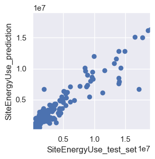

```python
# Comparison between ypred and ytest
plt.figure(figsize=(3, 3))
plt.plot(ytest_select, ypred_select, 'o')
plt.xlabel('SiteEnergyUse_test_set')
plt.xlim([min([ytest_select.min(), ypred_select.min()]), max([ytest_select.max(), ypred_select.max()])])
plt.ylabel('SiteEnergyUse_prediction')
plt.ylim([min([ytest_select.min(), ypred_select.min()]), max([ytest_select.max(), ypred_select.max()])])
plt.show()
```

Comparing this scatter plot with the previous one, the predicted values of SiteEnergyUse is more accurate when using ENERGYSTARScore.

##### ii) Features importance

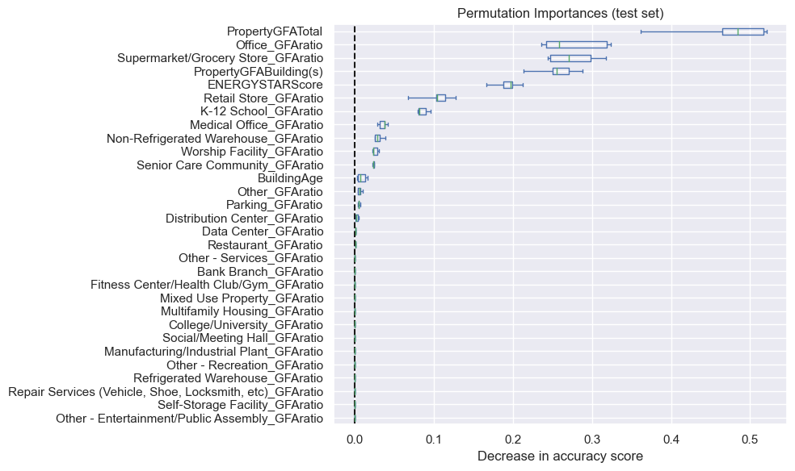

```python
# fit the model
estimator.fit(xtrain_select, ytrain_select)
# perform permutation importance
result = permutation_importance(estimator, xtest, ytest,
                                n_repeats=5, random_state=42, n_jobs=-1)

# get importance
sorted_importances_idx = result.importances_mean.argsort()
importances = pd.DataFrame(result.importances[sorted_importances_idx].T,
                           columns=xtrain_select.columns[sorted_importances_idx])

ax = importances.plot.box(vert=False, whis=10, figsize=(10, 6))
ax.set_title('Permutation Importances (test set)')
ax.axvline(x=0, color='k', linestyle='--')
ax.set_xlabel('Decrease in accuracy score')
ax.figure.tight_layout()
```

We see that ENERGYSTARScore occupy the 5th position in terms of Importance.

### D. Summary

- Best model in terms of highest r2 score is **KernelRidge** for the prediction of **SiteEnergyUse**.
- The final list of columns is: **PropertyGFATotal, PropertyGFABuilding(s), all columns ending with GFAratio, and BuildingAge**.
- **ENERGYSTARSCore gave better score** for the prediction. It can be **added to the final list of columns**.